# Risk Factor Analysis

## Outcome Variable

**Outcome Variable:** ever_wasted

## Predictor Variables

**Intervention Variable:** perdiar6

**Adjustment Set:**

- arm
- sex
- W_mage
- meducyrs
- feducyrs
- hhwealth_quart
- hfoodsec
- W_mhtcm
- W_mwtkg
- W_mbmi
- W_birthwt
- W_birthlen
- W_nrooms
- month
- brthmon
- impfloor
- impsan
- safeh20
- delta_W_mage
- delta_meducyrs
- delta_feducyrs
- delta_hhwealth_quart
- delta_hfoodsec
- delta_W_mhtcm
- delta_W_mwtkg
- delta_W_mbmi
- delta_W_birthwt
- delta_W_birthlen
- delta_W_nrooms
- delta_month
- delta_brthmon
- delta_impfloor
- delta_impsan
- delta_safeh20

## Stratifying Variables

The analysis was stratified on these variable(s):

- agecat
- studyid
- country

## Data Summary

| agecat | studyid | country | perdiar6 | ever_wasted | n_cell | n |
| --- | --- | --- | --- | --- | --- | --- |
| 0-24 months (no birth wast) | ki0047075b-MAL-ED | BANGLADESH | 0% | 0 | 65 | 263 |
| 0-24 months (no birth wast) | ki0047075b-MAL-ED | BANGLADESH | 0% | 1 | 20 | 263 |
| 0-24 months (no birth wast) | ki0047075b-MAL-ED | BANGLADESH | (0%, 5%] | 0 | 75 | 263 |
| 0-24 months (no birth wast) | ki0047075b-MAL-ED | BANGLADESH | (0%, 5%] | 1 | 23 | 263 |
| 0-24 months (no birth wast) | ki0047075b-MAL-ED | BANGLADESH | >5% | 0 | 65 | 263 |
| 0-24 months (no birth wast) | ki0047075b-MAL-ED | BANGLADESH | >5% | 1 | 15 | 263 |
| 0-24 months (no birth wast) | ki0047075b-MAL-ED | BRAZIL | 0% | 0 | 205 | 233 |
| 0-24 months (no birth wast) | ki0047075b-MAL-ED | BRAZIL | 0% | 1 | 11 | 233 |
| 0-24 months (no birth wast) | ki0047075b-MAL-ED | BRAZIL | (0%, 5%] | 0 | 14 | 233 |
| 0-24 months (no birth wast) | ki0047075b-MAL-ED | BRAZIL | (0%, 5%] | 1 | 1 | 233 |
| 0-24 months (no birth wast) | ki0047075b-MAL-ED | BRAZIL | >5% | 0 | 1 | 233 |
| 0-24 months (no birth wast) | ki0047075b-MAL-ED | BRAZIL | >5% | 1 | 1 | 233 |
| 0-24 months (no birth wast) | ki0047075b-MAL-ED | INDIA | 0% | 0 | 35 | 246 |
| 0-24 months (no birth wast) | ki0047075b-MAL-ED | INDIA | 0% | 1 | 24 | 246 |
| 0-24 months (no birth wast) | ki0047075b-MAL-ED | INDIA | (0%, 5%] | 0 | 85 | 246 |
| 0-24 months (no birth wast) | ki0047075b-MAL-ED | INDIA | (0%, 5%] | 1 | 43 | 246 |
| 0-24 months (no birth wast) | ki0047075b-MAL-ED | INDIA | >5% | 0 | 35 | 246 |
| 0-24 months (no birth wast) | ki0047075b-MAL-ED | INDIA | >5% | 1 | 24 | 246 |
| 0-24 months (no birth wast) | ki0047075b-MAL-ED | NEPAL | 0% | 0 | 65 | 239 |
| 0-24 months (no birth wast) | ki0047075b-MAL-ED | NEPAL | 0% | 1 | 18 | 239 |
| 0-24 months (no birth wast) | ki0047075b-MAL-ED | NEPAL | (0%, 5%] | 0 | 63 | 239 |
| 0-24 months (no birth wast) | ki0047075b-MAL-ED | NEPAL | (0%, 5%] | 1 | 13 | 239 |
| 0-24 months (no birth wast) | ki0047075b-MAL-ED | NEPAL | >5% | 0 | 65 | 239 |
| 0-24 months (no birth wast) | ki0047075b-MAL-ED | NEPAL | >5% | 1 | 15 | 239 |
| 0-24 months (no birth wast) | ki0047075b-MAL-ED | PERU | 0% | 0 | 83 | 302 |
| 0-24 months (no birth wast) | ki0047075b-MAL-ED | PERU | 0% | 1 | 6 | 302 |
| 0-24 months (no birth wast) | ki0047075b-MAL-ED | PERU | (0%, 5%] | 0 | 88 | 302 |
| 0-24 months (no birth wast) | ki0047075b-MAL-ED | PERU | (0%, 5%] | 1 | 5 | 302 |
| 0-24 months (no birth wast) | ki0047075b-MAL-ED | PERU | >5% | 0 | 110 | 302 |
| 0-24 months (no birth wast) | ki0047075b-MAL-ED | PERU | >5% | 1 | 10 | 302 |

[output cut: 204 more lines]

The following strata were considered:

- agecat: 0-24 months (no birth wast), studyid: ki0047075b-MAL-ED, country: BANGLADESH
- agecat: 0-24 months (no birth wast), studyid: ki0047075b-MAL-ED, country: BRAZIL
- agecat: 0-24 months (no birth wast), studyid: ki0047075b-MAL-ED, country: INDIA
- agecat: 0-24 months (no birth wast), studyid: ki0047075b-MAL-ED, country: NEPAL
- agecat: 0-24 months (no birth wast), studyid: ki0047075b-MAL-ED, country: PERU
- agecat: 0-24 months (no birth wast), studyid: ki0047075b-MAL-ED, country: SOUTH AFRICA
- agecat: 0-24 months (no birth wast), studyid: ki0047075b-MAL-ED, country: TANZANIA, UNITED REPUBLIC OF
- agecat: 0-24 months (no birth wast), studyid: ki1000109-EE, country: PAKISTAN
- agecat: 0-24 months (no birth wast), studyid: ki1017093-NIH-Birth, country: BANGLADESH
- agecat: 0-24 months (no birth wast), studyid: ki1017093b-PROVIDE, country: BANGLADESH
- agecat: 0-24 months (no birth wast), studyid: ki1017093c-NIH-Crypto, country: BANGLADESH
- agecat: 0-24 months (no birth wast), studyid: ki1114097-CMIN, country: BANGLADESH
- agecat: 0-24 months (no birth wast), studyid: ki1114097-CONTENT, country: PERU
- agecat: 0-6 months (no birth wast), studyid: ki0047075b-MAL-ED, country: BANGLADESH
- agecat: 0-6 months (no birth wast), studyid: ki0047075b-MAL-ED, country: BRAZIL
- agecat: 0-6 months (no birth wast), studyid: ki0047075b-MAL-ED, country: INDIA
- agecat: 0-6 months (no birth wast), studyid: ki0047075b-MAL-ED, country: NEPAL
- agecat: 0-6 months (no birth wast), studyid: ki0047075b-MAL-ED, country: PERU
- agecat: 0-6 months (no birth wast), studyid: ki0047075b-MAL-ED, country: SOUTH AFRICA
- agecat: 0-6 months (no birth wast), studyid: ki0047075b-MAL-ED, country: TANZANIA, UNITED REPUBLIC OF
- agecat: 0-6 months (no birth wast), studyid: ki1000109-EE, country: PAKISTAN
- agecat: 0-6 months (no birth wast), studyid: ki1017093-NIH-Birth, country: BANGLADESH
- agecat: 0-6 months (no birth wast), studyid: ki1017093b-PROVIDE, country: BANGLADESH
- agecat: 0-6 months (no birth wast), studyid: ki1017093c-NIH-Crypto, country: BANGLADESH
- agecat: 0-6 months (no birth wast), studyid: ki1114097-CMIN, country: BANGLADESH
- agecat: 0-6 months (no birth wast), studyid: ki1114097-CONTENT, country: PERU
- agecat: 6-24 months, studyid: ki0047075b-MAL-ED, country: BANGLADESH
- agecat: 6-24 months, studyid: ki0047075b-MAL-ED, country: BRAZIL
- agecat: 6-24 months, studyid: ki0047075b-MAL-ED, country: INDIA
- agecat: 6-24 months, studyid: ki0047075b-MAL-ED, country: NEPAL
- agecat: 6-24 months, studyid: ki0047075b-MAL-ED, country: PERU
- agecat: 6-24 months, studyid: ki0047075b-MAL-ED, country: SOUTH AFRICA
- agecat: 6-24 months, studyid: ki0047075b-MAL-ED, country: TANZANIA, UNITED REPUBLIC OF
- agecat: 6-24 months, studyid: ki1000109-EE, country: PAKISTAN
- agecat: 6-24 months, studyid: ki1017093-NIH-Birth, country: BANGLADESH
- agecat: 6-24 months, studyid: ki1017093b-PROVIDE, country: BANGLADESH
- agecat: 6-24 months, studyid: ki1017093c-NIH-Crypto, country: BANGLADESH
- agecat: 6-24 months, studyid: ki1114097-CMIN, country: BANGLADESH
- agecat: 6-24 months, studyid: ki1114097-CONTENT, country: PERU

### Dropped Strata

Some strata were dropped due to rare outcomes:

- agecat: 0-24 months (no birth wast), studyid: ki0047075b-MAL-ED, country: BRAZIL
- agecat: 0-24 months (no birth wast), studyid: ki0047075b-MAL-ED, country: SOUTH AFRICA
- agecat: 0-24 months (no birth wast), studyid: ki0047075b-MAL-ED, country: TANZANIA, UNITED REPUBLIC OF
- agecat: 0-24 months (no birth wast), studyid: ki1000109-EE, country: PAKISTAN
- agecat: 0-24 months (no birth wast), studyid: ki1114097-CONTENT, country: PERU
- agecat: 0-6 months (no birth wast), studyid: ki0047075b-MAL-ED, country: BRAZIL
- agecat: 0-6 months (no birth wast), studyid: ki0047075b-MAL-ED, country: NEPAL
- agecat: 0-6 months (no birth wast), studyid: ki0047075b-MAL-ED, country: PERU
- agecat: 0-6 months (no birth wast), studyid: ki0047075b-MAL-ED, country: SOUTH AFRICA
- agecat: 0-6 months (no birth wast), studyid: ki0047075b-MAL-ED, country: TANZANIA, UNITED REPUBLIC OF
- agecat: 0-6 months (no birth wast), studyid: ki1000109-EE, country: PAKISTAN
- agecat: 0-6 months (no birth wast), studyid: ki1114097-CONTENT, country: PERU
- agecat: 6-24 months, studyid: ki0047075b-MAL-ED, country: BRAZIL
- agecat: 6-24 months, studyid: ki0047075b-MAL-ED, country: PERU
- agecat: 6-24 months, studyid: ki0047075b-MAL-ED, country: SOUTH AFRICA
- agecat: 6-24 months, studyid: ki0047075b-MAL-ED, country: TANZANIA, UNITED REPUBLIC OF
- agecat: 6-24 months, studyid: ki1000109-EE, country: PAKISTAN
- agecat: 6-24 months, studyid: ki1114097-CONTENT, country: PERU

## Methods Detail

We’re interested in the causal parameters $E[Y_a]$ for all values of $a \in \mathcal{A}$. These parameters represent the mean outcome if, possibly contrary to fact, we intervened to set all units to have $A=a$. Under the randomization and positivity assumptions, these are identified by the statistical parameters $\psi_a=E_W[E_{Y|A,W}(Y|A=a,W)]$. In addition, we’re interested in the mean of $Y$, $E[Y]$ under no intervention (the observed mean). We will estimate these parameters by using SuperLearner to fit the relevant likelihood factors – $E_{Y|A,W}(Y|A=a,W)$ and $p(A=a|W)$, and then updating our likelihood fit using a joint TMLE.

For unadjusted analyses ($W=\{\}$), initial likelihoods were estimated using Lrnr_glm to estimate the simple $E(Y|A)$ and Lrnr_mean to estimate $p(A)$. For adjusted analyses, a small library containing Lrnr_glmnet, Lrnr_xgboost, and Lrnr_mean was used.

Having estimated these parameters, we will then use the delta method to estimate relative risks and attributable risks relative to a prespecified baseline level of $A$.

# Results Detail

## Results Plots

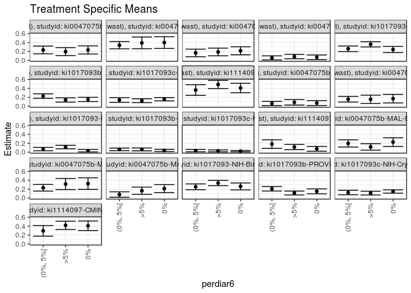

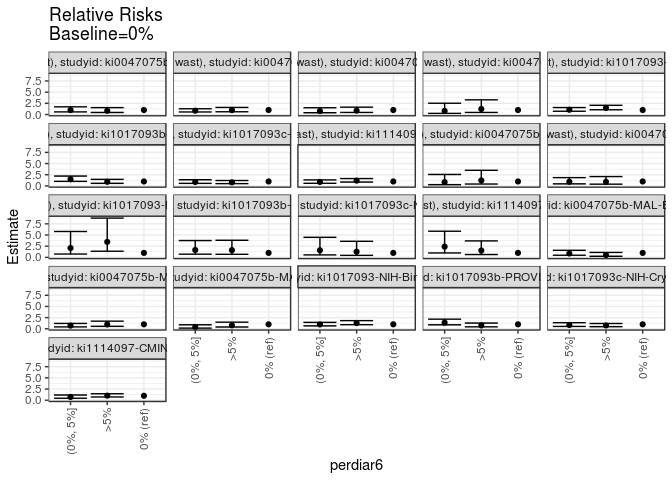

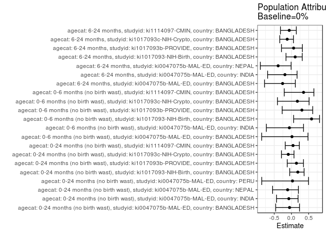

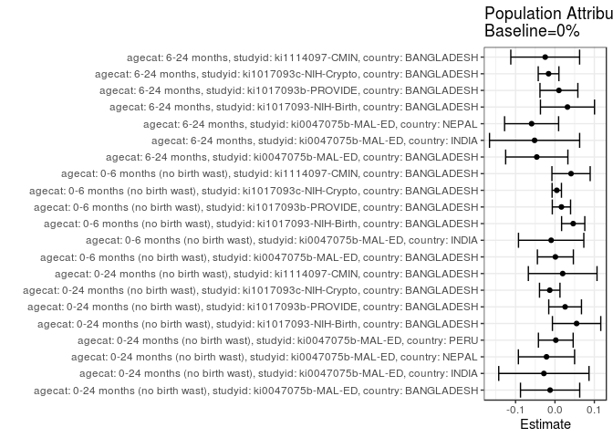

## Results Table

### Parameter: TSM

| agecat | studyid | country | intervention_level | baseline_level | estimate | ci_lower | ci_upper |
| --- | --- | --- | --- | --- | --- | --- | --- |
| 0-24 months (no birth wast) | ki0047075b-MAL-ED | BANGLADESH | 0% | NA | 0.2328752 | 0.1410967 | 0.3246536 |
| 0-24 months (no birth wast) | ki0047075b-MAL-ED | BANGLADESH | (0%, 5%] | NA | 0.2325455 | 0.1454654 | 0.3196256 |
| 0-24 months (no birth wast) | ki0047075b-MAL-ED | BANGLADESH | >5% | NA | 0.1947753 | 0.1049899 | 0.2845606 |
| 0-24 months (no birth wast) | ki0047075b-MAL-ED | INDIA | 0% | NA | 0.3980625 | 0.2660987 | 0.5300263 |
| 0-24 months (no birth wast) | ki0047075b-MAL-ED | INDIA | (0%, 5%] | NA | 0.3391873 | 0.2578259 | 0.4205486 |
| 0-24 months (no birth wast) | ki0047075b-MAL-ED | INDIA | >5% | NA | 0.3916129 | 0.2595064 | 0.5237194 |
| 0-24 months (no birth wast) | ki0047075b-MAL-ED | NEPAL | 0% | NA | 0.2139528 | 0.1239408 | 0.3039648 |
| 0-24 months (no birth wast) | ki0047075b-MAL-ED | NEPAL | (0%, 5%] | NA | 0.1649320 | 0.0794325 | 0.2504315 |
| 0-24 months (no birth wast) | ki0047075b-MAL-ED | NEPAL | >5% | NA | 0.1871718 | 0.1006996 | 0.2736440 |
| 0-24 months (no birth wast) | ki0047075b-MAL-ED | PERU | 0% | NA | 0.0674157 | 0.0152365 | 0.1195950 |
| 0-24 months (no birth wast) | ki0047075b-MAL-ED | PERU | (0%, 5%] | NA | 0.0537634 | 0.0078468 | 0.0996801 |
| 0-24 months (no birth wast) | ki0047075b-MAL-ED | PERU | >5% | NA | 0.0833333 | 0.0338005 | 0.1328661 |
| 0-24 months (no birth wast) | ki1017093-NIH-Birth | BANGLADESH | 0% | NA | 0.2422353 | 0.1727159 | 0.3117546 |
| 0-24 months (no birth wast) | ki1017093-NIH-Birth | BANGLADESH | (0%, 5%] | NA | 0.2578874 | 0.1945741 | 0.3212007 |
| 0-24 months (no birth wast) | ki1017093-NIH-Birth | BANGLADESH | >5% | NA | 0.3587146 | 0.3000355 | 0.4173937 |
| 0-24 months (no birth wast) | ki1017093b-PROVIDE | BANGLADESH | 0% | NA | 0.1518039 | 0.1039249 | 0.1996829 |
| 0-24 months (no birth wast) | ki1017093b-PROVIDE | BANGLADESH | (0%, 5%] | NA | 0.2276621 | 0.1765097 | 0.2788146 |
| 0-24 months (no birth wast) | ki1017093b-PROVIDE | BANGLADESH | >5% | NA | 0.1403900 | 0.0929162 | 0.1878637 |
| 0-24 months (no birth wast) | ki1017093c-NIH-Crypto | BANGLADESH | 0% | NA | 0.1564911 | 0.1191378 | 0.1938443 |
| 0-24 months (no birth wast) | ki1017093c-NIH-Crypto | BANGLADESH | (0%, 5%] | NA | 0.1394913 | 0.0874009 | 0.1915816 |
| 0-24 months (no birth wast) | ki1017093c-NIH-Crypto | BANGLADESH | >5% | NA | 0.1243568 | 0.0803466 | 0.1683669 |
| 0-24 months (no birth wast) | ki1114097-CMIN | BANGLADESH | 0% | NA | 0.4094926 | 0.3034156 | 0.5155696 |
| 0-24 months (no birth wast) | ki1114097-CMIN | BANGLADESH | (0%, 5%] | NA | 0.3643802 | 0.2442470 | 0.4845133 |
| 0-24 months (no birth wast) | ki1114097-CMIN | BANGLADESH | >5% | NA | 0.4884960 | 0.3956164 | 0.5813756 |
| 0-6 months (no birth wast) | ki0047075b-MAL-ED | BANGLADESH | 0% | NA | 0.0714286 | 0.0162485 | 0.1266087 |
| 0-6 months (no birth wast) | ki0047075b-MAL-ED | BANGLADESH | (0%, 5%] | NA | 0.0612245 | 0.0136681 | 0.1087809 |
| 0-6 months (no birth wast) | ki0047075b-MAL-ED | BANGLADESH | >5% | NA | 0.0875000 | 0.0254625 | 0.1495375 |
| 0-6 months (no birth wast) | ki0047075b-MAL-ED | INDIA | 0% | NA | 0.1694915 | 0.0735603 | 0.2654227 |
| 0-6 months (no birth wast) | ki0047075b-MAL-ED | INDIA | (0%, 5%] | NA | 0.1574803 | 0.0939997 | 0.2209609 |
| 0-6 months (no birth wast) | ki0047075b-MAL-ED | INDIA | >5% | NA | 0.1551724 | 0.0618003 | 0.2485445 |
| 0-6 months (no birth wast) | ki1017093-NIH-Birth | BANGLADESH | 0% | NA | 0.0328947 | 0.0045155 | 0.0612740 |
| 0-6 months (no birth wast) | ki1017093-NIH-Birth | BANGLADESH | (0%, 5%] | NA | 0.0685714 | 0.0310957 | 0.1060471 |
| 0-6 months (no birth wast) | ki1017093-NIH-Birth | BANGLADESH | >5% | NA | 0.1141732 | 0.0750295 | 0.1533169 |
| 0-6 months (no birth wast) | ki1017093b-PROVIDE | BANGLADESH | 0% | NA | 0.0377358 | 0.0120660 | 0.0634057 |
| 0-6 months (no birth wast) | ki1017093b-PROVIDE | BANGLADESH | (0%, 5%] | NA | 0.0620155 | 0.0325642 | 0.0914668 |
| 0-6 months (no birth wast) | ki1017093b-PROVIDE | BANGLADESH | >5% | NA | 0.0610329 | 0.0288605 | 0.0932053 |
| 0-6 months (no birth wast) | ki1017093c-NIH-Crypto | BANGLADESH | 0% | NA | 0.0220994 | 0.0069456 | 0.0372533 |
| 0-6 months (no birth wast) | ki1017093c-NIH-Crypto | BANGLADESH | (0%, 5%] | NA | 0.0348837 | 0.0074443 | 0.0623232 |
| 0-6 months (no birth wast) | ki1017093c-NIH-Crypto | BANGLADESH | >5% | NA | 0.0279070 | 0.0058762 | 0.0499377 |
| 0-6 months (no birth wast) | ki1114097-CMIN | BANGLADESH | 0% | NA | 0.0752688 | 0.0215487 | 0.1289889 |
| 0-6 months (no birth wast) | ki1114097-CMIN | BANGLADESH | (0%, 5%] | NA | 0.1803279 | 0.0836673 | 0.2769885 |
| 0-6 months (no birth wast) | ki1114097-CMIN | BANGLADESH | >5% | NA | 0.1150442 | 0.0561033 | 0.1739852 |
| 6-24 months | ki0047075b-MAL-ED | BANGLADESH | 0% | NA | 0.2253521 | 0.1279634 | 0.3227408 |
| 6-24 months | ki0047075b-MAL-ED | BANGLADESH | (0%, 5%] | NA | 0.1956522 | 0.1144206 | 0.2768838 |
| 6-24 months | ki0047075b-MAL-ED | BANGLADESH | >5% | NA | 0.1168831 | 0.0449723 | 0.1887940 |
| 6-24 months | ki0047075b-MAL-ED | INDIA | 0% | NA | 0.3240848 | 0.1939585 | 0.4542110 |
| 6-24 months | ki0047075b-MAL-ED | INDIA | (0%, 5%] | NA | 0.2314449 | 0.1570259 | 0.3058638 |
| 6-24 months | ki0047075b-MAL-ED | INDIA | >5% | NA | 0.3146994 | 0.1900858 | 0.4393130 |
| 6-24 months | ki0047075b-MAL-ED | NEPAL | 0% | NA | 0.2125000 | 0.1226674 | 0.3023326 |
| 6-24 months | ki0047075b-MAL-ED | NEPAL | (0%, 5%] | NA | 0.0789474 | 0.0181929 | 0.1397019 |
| 6-24 months | ki0047075b-MAL-ED | NEPAL | >5% | NA | 0.1645570 | 0.0826205 | 0.2464934 |
| 6-24 months | ki1017093-NIH-Birth | BANGLADESH | 0% | NA | 0.2615638 | 0.1839952 | 0.3391323 |
| 6-24 months | ki1017093-NIH-Birth | BANGLADESH | (0%, 5%] | NA | 0.2529388 | 0.1880720 | 0.3178057 |
| 6-24 months | ki1017093-NIH-Birth | BANGLADESH | >5% | NA | 0.3378471 | 0.2777080 | 0.3979862 |
| 6-24 months | ki1017093b-PROVIDE | BANGLADESH | 0% | NA | 0.1509267 | 0.0956279 | 0.2062255 |
| 6-24 months | ki1017093b-PROVIDE | BANGLADESH | (0%, 5%] | NA | 0.2090960 | 0.1584555 | 0.2597364 |
| 6-24 months | ki1017093b-PROVIDE | BANGLADESH | >5% | NA | 0.1135008 | 0.0698075 | 0.1571942 |
| 6-24 months | ki1017093c-NIH-Crypto | BANGLADESH | 0% | NA | 0.1477405 | 0.1100570 | 0.1854240 |
| 6-24 months | ki1017093c-NIH-Crypto | BANGLADESH | (0%, 5%] | NA | 0.1250974 | 0.0745565 | 0.1756384 |
| 6-24 months | ki1017093c-NIH-Crypto | BANGLADESH | >5% | NA | 0.1109043 | 0.0687085 | 0.1531001 |
| 6-24 months | ki1114097-CMIN | BANGLADESH | 0% | NA | 0.4096887 | 0.3023111 | 0.5170663 |
| 6-24 months | ki1114097-CMIN | BANGLADESH | (0%, 5%] | NA | 0.2952501 | 0.1758608 | 0.4146393 |
| 6-24 months | ki1114097-CMIN | BANGLADESH | >5% | NA | 0.4188578 | 0.3254720 | 0.5122436 |

### Parameter: E(Y)

| agecat | studyid | country | intervention_level | baseline_level | estimate | ci_lower | ci_upper |
| --- | --- | --- | --- | --- | --- | --- | --- |
| 0-24 months (no birth wast) | ki0047075b-MAL-ED | BANGLADESH | NA | NA | 0.2205323 | 0.1703290 | 0.2707357 |
| 0-24 months (no birth wast) | ki0047075b-MAL-ED | INDIA | NA | NA | 0.3699187 | 0.3094659 | 0.4303715 |
| 0-24 months (no birth wast) | ki0047075b-MAL-ED | NEPAL | NA | NA | 0.1924686 | 0.1423823 | 0.2425550 |
| 0-24 months (no birth wast) | ki0047075b-MAL-ED | PERU | NA | NA | 0.0695364 | 0.0408008 | 0.0982721 |
| 0-24 months (no birth wast) | ki1017093-NIH-Birth | BANGLADESH | NA | NA | 0.2971619 | 0.2605332 | 0.3337907 |
| 0-24 months (no birth wast) | ki1017093b-PROVIDE | BANGLADESH | NA | NA | 0.1775837 | 0.1489858 | 0.2061816 |
| 0-24 months (no birth wast) | ki1017093c-NIH-Crypto | BANGLADESH | NA | NA | 0.1432361 | 0.1182149 | 0.1682572 |
| 0-24 months (no birth wast) | ki1114097-CMIN | BANGLADESH | NA | NA | 0.4291045 | 0.3697365 | 0.4884725 |
| 0-6 months (no birth wast) | ki0047075b-MAL-ED | BANGLADESH | NA | NA | 0.0725191 | 0.0410556 | 0.1039825 |
| 0-6 months (no birth wast) | ki0047075b-MAL-ED | INDIA | NA | NA | 0.1598361 | 0.1137612 | 0.2059110 |
| 0-6 months (no birth wast) | ki1017093-NIH-Birth | BANGLADESH | NA | NA | 0.0791738 | 0.0571996 | 0.1011481 |
| 0-6 months (no birth wast) | ki1017093b-PROVIDE | BANGLADESH | NA | NA | 0.0541728 | 0.0371844 | 0.0711612 |
| 0-6 months (no birth wast) | ki1017093c-NIH-Crypto | BANGLADESH | NA | NA | 0.0267023 | 0.0151493 | 0.0382553 |
| 0-6 months (no birth wast) | ki1114097-CMIN | BANGLADESH | NA | NA | 0.1161049 | 0.0776073 | 0.1546024 |
| 6-24 months | ki0047075b-MAL-ED | BANGLADESH | NA | NA | 0.1791667 | 0.1305478 | 0.2277856 |
| 6-24 months | ki0047075b-MAL-ED | INDIA | NA | NA | 0.2723404 | 0.2153029 | 0.3293779 |
| 6-24 months | ki0047075b-MAL-ED | NEPAL | NA | NA | 0.1531915 | 0.1070438 | 0.1993392 |
| 6-24 months | ki1017093-NIH-Birth | BANGLADESH | NA | NA | 0.2933579 | 0.2549918 | 0.3317241 |
| 6-24 months | ki1017093b-PROVIDE | BANGLADESH | NA | NA | 0.1609756 | 0.1319065 | 0.1900447 |
| 6-24 months | ki1017093c-NIH-Crypto | BANGLADESH | NA | NA | 0.1315068 | 0.1069744 | 0.1560393 |
| 6-24 months | ki1114097-CMIN | BANGLADESH | NA | NA | 0.3849206 | 0.3247254 | 0.4451159 |

### Parameter: RR

| agecat | studyid | country | intervention_level | baseline_level | estimate | ci_lower | ci_upper |
| --- | --- | --- | --- | --- | --- | --- | --- |
| 0-24 months (no birth wast) | ki0047075b-MAL-ED | BANGLADESH | 0% | 0% | 1.0000000 | 1.0000000 | 1.0000000 |
| 0-24 months (no birth wast) | ki0047075b-MAL-ED | BANGLADESH | (0%, 5%] | 0% | 0.9985843 | 0.5794094 | 1.7210121 |
| 0-24 months (no birth wast) | ki0047075b-MAL-ED | BANGLADESH | >5% | 0% | 0.8363934 | 0.4556004 | 1.5354551 |
| 0-24 months (no birth wast) | ki0047075b-MAL-ED | INDIA | 0% | 0% | 1.0000000 | 1.0000000 | 1.0000000 |
| 0-24 months (no birth wast) | ki0047075b-MAL-ED | INDIA | (0%, 5%] | 0% | 0.8520955 | 0.5656094 | 1.2836892 |
| 0-24 months (no birth wast) | ki0047075b-MAL-ED | INDIA | >5% | 0% | 0.9837975 | 0.6116809 | 1.5822915 |
| 0-24 months (no birth wast) | ki0047075b-MAL-ED | NEPAL | 0% | 0% | 1.0000000 | 1.0000000 | 1.0000000 |
| 0-24 months (no birth wast) | ki0047075b-MAL-ED | NEPAL | (0%, 5%] | 0% | 0.7708803 | 0.3949494 | 1.5046395 |
| 0-24 months (no birth wast) | ki0047075b-MAL-ED | NEPAL | >5% | 0% | 0.8748277 | 0.4673255 | 1.6376669 |
| 0-24 months (no birth wast) | ki0047075b-MAL-ED | PERU | 0% | 0% | 1.0000000 | 1.0000000 | 1.0000000 |
| 0-24 months (no birth wast) | ki0047075b-MAL-ED | PERU | (0%, 5%] | 0% | 0.7974910 | 0.2518616 | 2.5251640 |
| 0-24 months (no birth wast) | ki0047075b-MAL-ED | PERU | >5% | 0% | 1.2361111 | 0.4658353 | 3.2800664 |
| 0-24 months (no birth wast) | ki1017093-NIH-Birth | BANGLADESH | 0% | 0% | 1.0000000 | 1.0000000 | 1.0000000 |
| 0-24 months (no birth wast) | ki1017093-NIH-Birth | BANGLADESH | (0%, 5%] | 0% | 1.0646153 | 0.7303490 | 1.5518689 |
| 0-24 months (no birth wast) | ki1017093-NIH-Birth | BANGLADESH | >5% | 0% | 1.4808522 | 1.0646341 | 2.0597905 |
| 0-24 months (no birth wast) | ki1017093b-PROVIDE | BANGLADESH | 0% | 0% | 1.0000000 | 1.0000000 | 1.0000000 |
| 0-24 months (no birth wast) | ki1017093b-PROVIDE | BANGLADESH | (0%, 5%] | 0% | 1.4997117 | 1.0192412 | 2.2066761 |
| 0-24 months (no birth wast) | ki1017093b-PROVIDE | BANGLADESH | >5% | 0% | 0.9248112 | 0.5828639 | 1.4673679 |
| 0-24 months (no birth wast) | ki1017093c-NIH-Crypto | BANGLADESH | 0% | 0% | 1.0000000 | 1.0000000 | 1.0000000 |
| 0-24 months (no birth wast) | ki1017093c-NIH-Crypto | BANGLADESH | (0%, 5%] | 0% | 0.8913688 | 0.5721635 | 1.3886560 |
| 0-24 months (no birth wast) | ki1017093c-NIH-Crypto | BANGLADESH | >5% | 0% | 0.7946573 | 0.5185323 | 1.2178225 |
| 0-24 months (no birth wast) | ki1114097-CMIN | BANGLADESH | 0% | 0% | 1.0000000 | 1.0000000 | 1.0000000 |
| 0-24 months (no birth wast) | ki1114097-CMIN | BANGLADESH | (0%, 5%] | 0% | 0.8898334 | 0.5846798 | 1.3542516 |
| 0-24 months (no birth wast) | ki1114097-CMIN | BANGLADESH | >5% | 0% | 1.1929301 | 0.8641324 | 1.6468335 |
| 0-6 months (no birth wast) | ki0047075b-MAL-ED | BANGLADESH | 0% | 0% | 1.0000000 | 1.0000000 | 1.0000000 |
| 0-6 months (no birth wast) | ki0047075b-MAL-ED | BANGLADESH | (0%, 5%] | 0% | 0.8571429 | 0.2866027 | 2.5634573 |
| 0-6 months (no birth wast) | ki0047075b-MAL-ED | BANGLADESH | >5% | 0% | 1.2250000 | 0.4292932 | 3.4955711 |
| 0-6 months (no birth wast) | ki0047075b-MAL-ED | INDIA | 0% | 0% | 1.0000000 | 1.0000000 | 1.0000000 |
| 0-6 months (no birth wast) | ki0047075b-MAL-ED | INDIA | (0%, 5%] | 0% | 0.9291339 | 0.4637685 | 1.8614668 |
| 0-6 months (no birth wast) | ki0047075b-MAL-ED | INDIA | >5% | 0% | 0.9155172 | 0.4007733 | 2.0913862 |
| 0-6 months (no birth wast) | ki1017093-NIH-Birth | BANGLADESH | 0% | 0% | 1.0000000 | 1.0000000 | 1.0000000 |
| 0-6 months (no birth wast) | ki1017093-NIH-Birth | BANGLADESH | (0%, 5%] | 0% | 2.0845714 | 0.7507348 | 5.7882467 |
| 0-6 months (no birth wast) | ki1017093-NIH-Birth | BANGLADESH | >5% | 0% | 3.4708661 | 1.3716980 | 8.7824812 |
| 0-6 months (no birth wast) | ki1017093b-PROVIDE | BANGLADESH | 0% | 0% | 1.0000000 | 1.0000000 | 1.0000000 |
| 0-6 months (no birth wast) | ki1017093b-PROVIDE | BANGLADESH | (0%, 5%] | 0% | 1.6434109 | 0.7168794 | 3.7674385 |
| 0-6 months (no birth wast) | ki1017093b-PROVIDE | BANGLADESH | >5% | 0% | 1.6173709 | 0.6840090 | 3.8243481 |
| 0-6 months (no birth wast) | ki1017093c-NIH-Crypto | BANGLADESH | 0% | 0% | 1.0000000 | 1.0000000 | 1.0000000 |
| 0-6 months (no birth wast) | ki1017093c-NIH-Crypto | BANGLADESH | (0%, 5%] | 0% | 1.5784884 | 0.5559638 | 4.4816327 |
| 0-6 months (no birth wast) | ki1017093c-NIH-Crypto | BANGLADESH | >5% | 0% | 1.2627907 | 0.4438198 | 3.5929903 |
| 0-6 months (no birth wast) | ki1114097-CMIN | BANGLADESH | 0% | 0% | 1.0000000 | 1.0000000 | 1.0000000 |
| 0-6 months (no birth wast) | ki1114097-CMIN | BANGLADESH | (0%, 5%] | 0% | 2.3957845 | 0.9813036 | 5.8491418 |
| 0-6 months (no birth wast) | ki1114097-CMIN | BANGLADESH | >5% | 0% | 1.5284450 | 0.6348869 | 3.6796223 |
| 6-24 months | ki0047075b-MAL-ED | BANGLADESH | 0% | 0% | 1.0000000 | 1.0000000 | 1.0000000 |
| 6-24 months | ki0047075b-MAL-ED | BANGLADESH | (0%, 5%] | 0% | 0.8682065 | 0.4768229 | 1.5808440 |
| 6-24 months | ki0047075b-MAL-ED | BANGLADESH | >5% | 0% | 0.5186688 | 0.2445485 | 1.1000571 |
| 6-24 months | ki0047075b-MAL-ED | INDIA | 0% | 0% | 1.0000000 | 1.0000000 | 1.0000000 |
| 6-24 months | ki0047075b-MAL-ED | INDIA | (0%, 5%] | 0% | 0.7141492 | 0.4266107 | 1.1954908 |
| 6-24 months | ki0047075b-MAL-ED | INDIA | >5% | 0% | 0.9710404 | 0.5523372 | 1.7071445 |
| 6-24 months | ki0047075b-MAL-ED | NEPAL | 0% | 0% | 1.0000000 | 1.0000000 | 1.0000000 |
| 6-24 months | ki0047075b-MAL-ED | NEPAL | (0%, 5%] | 0% | 0.3715170 | 0.1544035 | 0.8939232 |
| 6-24 months | ki0047075b-MAL-ED | NEPAL | >5% | 0% | 0.7743857 | 0.4029837 | 1.4880830 |
| 6-24 months | ki1017093-NIH-Birth | BANGLADESH | 0% | 0% | 1.0000000 | 1.0000000 | 1.0000000 |
| 6-24 months | ki1017093-NIH-Birth | BANGLADESH | (0%, 5%] | 0% | 0.9670256 | 0.6533351 | 1.4313306 |
| 6-24 months | ki1017093-NIH-Birth | BANGLADESH | >5% | 0% | 1.2916432 | 0.9146239 | 1.8240747 |
| 6-24 months | ki1017093b-PROVIDE | BANGLADESH | 0% | 0% | 1.0000000 | 1.0000000 | 1.0000000 |
| 6-24 months | ki1017093b-PROVIDE | BANGLADESH | (0%, 5%] | 0% | 1.3854144 | 0.8929590 | 2.1494527 |
| 6-24 months | ki1017093b-PROVIDE | BANGLADESH | >5% | 0% | 0.7520264 | 0.4417888 | 1.2801226 |
| 6-24 months | ki1017093c-NIH-Crypto | BANGLADESH | 0% | 0% | 1.0000000 | 1.0000000 | 1.0000000 |
| 6-24 months | ki1017093c-NIH-Crypto | BANGLADESH | (0%, 5%] | 0% | 0.8467375 | 0.5253653 | 1.3646969 |
| 6-24 months | ki1017093c-NIH-Crypto | BANGLADESH | >5% | 0% | 0.7506697 | 0.4748781 | 1.1866306 |
| 6-24 months | ki1114097-CMIN | BANGLADESH | 0% | 0% | 1.0000000 | 1.0000000 | 1.0000000 |
| 6-24 months | ki1114097-CMIN | BANGLADESH | (0%, 5%] | 0% | 0.7206693 | 0.4444325 | 1.1686008 |
| 6-24 months | ki1114097-CMIN | BANGLADESH | >5% | 0% | 1.0223807 | 0.7247345 | 1.4422694 |

### Parameter: PAR

| agecat | studyid | country | intervention_level | baseline_level | estimate | ci_lower | ci_upper |
| --- | --- | --- | --- | --- | --- | --- | --- |
| 0-24 months (no birth wast) | ki0047075b-MAL-ED | BANGLADESH | 0% | NA | -0.0123429 | -0.0875130 | 0.0628273 |
| 0-24 months (no birth wast) | ki0047075b-MAL-ED | INDIA | 0% | NA | -0.0281438 | -0.1427308 | 0.0864432 |
| 0-24 months (no birth wast) | ki0047075b-MAL-ED | NEPAL | 0% | NA | -0.0214842 | -0.0928340 | 0.0498656 |
| 0-24 months (no birth wast) | ki0047075b-MAL-ED | PERU | 0% | NA | 0.0021207 | -0.0419662 | 0.0462076 |
| 0-24 months (no birth wast) | ki1017093-NIH-Birth | BANGLADESH | 0% | NA | 0.0549267 | -0.0064472 | 0.1163006 |
| 0-24 months (no birth wast) | ki1017093b-PROVIDE | BANGLADESH | 0% | NA | 0.0257798 | -0.0157551 | 0.0673147 |
| 0-24 months (no birth wast) | ki1017093c-NIH-Crypto | BANGLADESH | 0% | NA | -0.0132550 | -0.0392303 | 0.0127203 |
| 0-24 months (no birth wast) | ki1114097-CMIN | BANGLADESH | 0% | NA | 0.0196119 | -0.0675541 | 0.1067780 |
| 0-6 months (no birth wast) | ki0047075b-MAL-ED | BANGLADESH | 0% | NA | 0.0010905 | -0.0445425 | 0.0467235 |
| 0-6 months (no birth wast) | ki0047075b-MAL-ED | INDIA | 0% | NA | -0.0096555 | -0.0925720 | 0.0732611 |
| 0-6 months (no birth wast) | ki1017093-NIH-Birth | BANGLADESH | 0% | NA | 0.0462791 | 0.0168369 | 0.0757213 |
| 0-6 months (no birth wast) | ki1017093b-PROVIDE | BANGLADESH | 0% | NA | 0.0164369 | -0.0067683 | 0.0396421 |
| 0-6 months (no birth wast) | ki1017093c-NIH-Crypto | BANGLADESH | 0% | NA | 0.0046028 | -0.0072773 | 0.0164829 |
| 0-6 months (no birth wast) | ki1114097-CMIN | BANGLADESH | 0% | NA | 0.0408361 | -0.0077185 | 0.0893906 |
| 6-24 months | ki0047075b-MAL-ED | BANGLADESH | 0% | NA | -0.0461854 | -0.1251580 | 0.0327871 |
| 6-24 months | ki0047075b-MAL-ED | INDIA | 0% | NA | -0.0517443 | -0.1661407 | 0.0626520 |
| 6-24 months | ki0047075b-MAL-ED | NEPAL | 0% | NA | -0.0593085 | -0.1279023 | 0.0092853 |
| 6-24 months | ki1017093-NIH-Birth | BANGLADESH | 0% | NA | 0.0317942 | -0.0368449 | 0.1004333 |
| 6-24 months | ki1017093b-PROVIDE | BANGLADESH | 0% | NA | 0.0100490 | -0.0380352 | 0.0581331 |
| 6-24 months | ki1017093c-NIH-Crypto | BANGLADESH | 0% | NA | -0.0162337 | -0.0424719 | 0.0100046 |
| 6-24 months | ki1114097-CMIN | BANGLADESH | 0% | NA | -0.0247681 | -0.1121115 | 0.0625753 |

### Parameter: PAF

| agecat | studyid | country | intervention_level | baseline_level | estimate | ci_lower | ci_upper |
| --- | --- | --- | --- | --- | --- | --- | --- |
| 0-24 months (no birth wast) | ki0047075b-MAL-ED | BANGLADESH | 0% | NA | -0.0559685 | -0.4580094 | 0.2352111 |
| 0-24 months (no birth wast) | ki0047075b-MAL-ED | INDIA | 0% | NA | -0.0760811 | -0.4346116 | 0.1928475 |
| 0-24 months (no birth wast) | ki0047075b-MAL-ED | NEPAL | 0% | NA | -0.1116243 | -0.5503657 | 0.2029567 |
| 0-24 months (no birth wast) | ki0047075b-MAL-ED | PERU | 0% | NA | 0.0304976 | -0.8642767 | 0.4958179 |
| 0-24 months (no birth wast) | ki1017093-NIH-Birth | BANGLADESH | 0% | NA | 0.1848375 | -0.0500377 | 0.3671752 |
| 0-24 months (no birth wast) | ki1017093b-PROVIDE | BANGLADESH | 0% | NA | 0.1451697 | -0.1221362 | 0.3488003 |
| 0-24 months (no birth wast) | ki1017093c-NIH-Crypto | BANGLADESH | 0% | NA | -0.0925396 | -0.2892673 | 0.0741697 |
| 0-24 months (no birth wast) | ki1114097-CMIN | BANGLADESH | 0% | NA | 0.0457043 | -0.1808896 | 0.2288184 |
| 0-6 months (no birth wast) | ki0047075b-MAL-ED | BANGLADESH | 0% | NA | 0.0150376 | -0.8657846 | 0.4800306 |
| 0-6 months (no birth wast) | ki0047075b-MAL-ED | INDIA | 0% | NA | -0.0604085 | -0.7292670 | 0.3497440 |
| 0-6 months (no birth wast) | ki1017093-NIH-Birth | BANGLADESH | 0% | NA | 0.5845252 | 0.0640759 | 0.8155627 |
| 0-6 months (no birth wast) | ki1017093b-PROVIDE | BANGLADESH | 0% | NA | 0.3034166 | -0.2702928 | 0.6180185 |
| 0-6 months (no birth wast) | ki1017093c-NIH-Crypto | BANGLADESH | 0% | NA | 0.1723757 | -0.4065203 | 0.5130095 |
| 0-6 months (no birth wast) | ki1114097-CMIN | BANGLADESH | 0% | NA | 0.3517170 | -0.2098491 | 0.6526254 |
| 6-24 months | ki0047075b-MAL-ED | BANGLADESH | 0% | NA | -0.2577792 | -0.7821004 | 0.1122786 |
| 6-24 months | ki0047075b-MAL-ED | INDIA | 0% | NA | -0.1899988 | -0.6938419 | 0.1639733 |
| 6-24 months | ki0047075b-MAL-ED | NEPAL | 0% | NA | -0.3871528 | -0.9051231 | -0.0100097 |
| 6-24 months | ki1017093-NIH-Birth | BANGLADESH | 0% | NA | 0.1083801 | -0.1591443 | 0.3141614 |
| 6-24 months | ki1017093b-PROVIDE | BANGLADESH | 0% | NA | 0.0624253 | -0.2890869 | 0.3180861 |
| 6-24 months | ki1017093c-NIH-Crypto | BANGLADESH | 0% | NA | -0.1234435 | -0.3405902 | 0.0585301 |
| 6-24 months | ki1114097-CMIN | BANGLADESH | 0% | NA | -0.0643459 | -0.3172089 | 0.1399753 |